# train_cnn

```python
import os, glob, numpy as np, pandas as pd
import matplotlib.pyplot as plt
plt.rcParams['figure.figsize'] = [25, 15]
plt.rcParams.update({'font.size': 18})
```

```python
def load_dataframe_from_files(dirin, fileprefix, max_files=100):
    import glob
    files = glob.glob(os.path.join(dirin, fileprefix))
    print("[Info] Loading {} files wt prefix:\n{}".format(len(files), fileprefix))
    df = pd.read_csv(files[0], comment='#', index_col=False)
    for file in files[1:max_files]:
        print(".", end='')
        dftmp = pd.read_csv(file, comment='#', index_col=False)
        df = pd.concat([df, dftmp])
    print("")
    return df
```

```python
dirin = os.path.join("..", "..", "Data", "OutputProcessing", "Ar39_07_09_2020", "Ar39_Snapshots")
fileinprefix = "Snapshot{}Ar39*.csv"

minPEcut = 5
ar39_dfs = []
ar39_dfs_names = []
for nPileups in range(1, 8):    # 2, 3, 4, 5, 6, 7
    df_ar39 = load_dataframe_from_files(dirin, fileinprefix.format(nPileups), max_files=100)
    df_ar39 = df_ar39[df_ar39.columns[:-1]]
    df_ar39 = df_ar39[df_ar39.pedetected>=minPEcut]
    ar39_dfs.append(df_ar39)
    ar39_dfs_names.append("{} Ar39 Pileup".format(nPileups))
del df_ar39
```

```
[Info] Loading 100 files wt prefix:
Snapshot1Ar39*.csv
...................................................................................................
[Info] Loading 100 files wt prefix:
Snapshot2Ar39*.csv
...................................................................................................
[Info] Loading 100 files wt prefix:
Snapshot3Ar39*.csv
...................................................................................................
[Info] Loading 100 files wt prefix:
Snapshot4Ar39*.csv
...................................................................................................
[Info] Loading 100 files wt prefix:
Snapshot5Ar39*.csv
...................................................................................................
[Info] Loading 100 files wt prefix:
Snapshot6Ar39*.csv
...................................................................................................
[Info] Loading 100 files wt prefix:
Snapshot7Ar39*.csv
...................................................................................................
```

```python
dirin = os.path.join("..", "..", "Data", "OutputProcessing", "Muons_07_09_2020", "Muons_Snapshots")
fileinprefix = "SnapshotMuon*.csv"

df_mu = load_dataframe_from_files(dirin, fileinprefix, max_files=200)
df_mu = df_mu[df_mu.pedetected>0]
df_mu = df_mu[df_mu.columns[:-1]]
```

```
[Info] Loading 200 files wt prefix:
SnapshotMuon*.csv
.......................................................................................................................................................................................................
```

## Data Selection: select events with overlapping energy spectrum

```python
for df_ar39, name in zip(ar39_dfs, ar39_dfs_names):
    print("[Info] {}: Min PE: {:.2f}, Mean PE: {:.2f}, Max PE: {:.2f}".format(name, df_ar39.pedetected.min(), df_ar39.pedetected.mean(), df_ar39.pedetected.max()))
```

```
[Info] 1 Ar39 Pileup: Min PE: 5.00, Mean PE: 8.52, Max PE: 60.00
[Info] 2 Ar39 Pileup: Min PE: 5.00, Mean PE: 9.47, Max PE: 63.00
[Info] 3 Ar39 Pileup: Min PE: 5.00, Mean PE: 11.31, Max PE: 78.00
[Info] 4 Ar39 Pileup: Min PE: 5.00, Mean PE: 14.16, Max PE: 79.00
[Info] 5 Ar39 Pileup: Min PE: 5.00, Mean PE: 17.57, Max PE: 94.00
[Info] 6 Ar39 Pileup: Min PE: 6.00, Mean PE: 21.09, Max PE: 113.00
[Info] 7 Ar39 Pileup: Min PE: 7.00, Mean PE: 24.60, Max PE: 99.00
```

```python
maxPEar39 = 115    # max is 113, 115 is a sort of upperbound (temporany)
df_lemu = df_mu[(df_mu.pedetected >= minPEcut) & (df_mu.pedetected <= maxPEar39)]
for df_ar39, name in zip(ar39_dfs, ar39_dfs_names):
    print("[Info] {}: Loaded {} Ar39 Pileups, with maximum {} PE detected".format(name, len(df_ar39), df_ar39.pedetected.max()))
print("[Info] Selected {} Muons, with maximum {} PE detected".format(len(df_lemu), df_lemu.pedetected.max()))
```

```
[Info] 1 Ar39 Pileup: Loaded 1474688 Ar39 Pileups, with maximum 60 PE detected
[Info] 2 Ar39 Pileup: Loaded 1947067 Ar39 Pileups, with maximum 63 PE detected
[Info] 3 Ar39 Pileup: Loaded 1890920 Ar39 Pileups, with maximum 78 PE detected
[Info] 4 Ar39 Pileup: Loaded 1561075 Ar39 Pileups, with maximum 79 PE detected
[Info] 5 Ar39 Pileup: Loaded 1261754 Ar39 Pileups, with maximum 94 PE detected
[Info] 6 Ar39 Pileup: Loaded 1051448 Ar39 Pileups, with maximum 113 PE detected
[Info] 7 Ar39 Pileup: Loaded 901235 Ar39 Pileups, with maximum 99 PE detected
[Info] Selected 6247 Muons, with maximum 115 PE detected
```

## Remove Test Data for later evaluation

```python
# Remove test data for later eval
n_test_mu, n_test_ar = 1000, 100000
# split mu data
id_mu = np.arange(len(df_lemu))
np.random.shuffle(id_mu)
muons_test, muons_train = df_lemu.iloc[id_mu[:n_test_mu], :], df_lemu.iloc[id_mu[n_test_mu:], :]
print("[Info] Muon Train {}, Test {}".format(len(muons_train), len(muons_test)))
# split ar39 data
ar39_dfs_train, ar39_dfs_test = [], []
for df_ar39, name in zip(ar39_dfs, ar39_dfs_names):
    id_ar = np.arange(len(df_ar39))
    np.random.shuffle(id_ar)
    ar39_test, ar39_train = df_ar39.iloc[id_ar[:n_test_ar], :], df_ar39.iloc[id_ar[n_test_ar:], :]
    ar39_dfs_train.append(ar39_train)
    ar39_dfs_test.append(ar39_test)
    print("[Info] {}: Ar39 Train {}, Test {}".format(name, len(ar39_train), len(ar39_test)))
```

```
[Info] Muon Train 5247, Test 1000
[Info] 1 Ar39 Pileup: Ar39 Train 1374688, Test 100000
[Info] 2 Ar39 Pileup: Ar39 Train 1847067, Test 100000
[Info] 3 Ar39 Pileup: Ar39 Train 1790920, Test 100000
[Info] 4 Ar39 Pileup: Ar39 Train 1461075, Test 100000
[Info] 5 Ar39 Pileup: Ar39 Train 1161754, Test 100000
[Info] 6 Ar39 Pileup: Ar39 Train 951448, Test 100000
[Info] 7 Ar39 Pileup: Ar39 Train 801235, Test 100000
```

## Augment Muons

Idea: since we aim to exploit topological information and the cylinder is symmetric, we can roll the inner/outer detections to augment the muon data.

However, the inner/outer shroud has a different diameter and then, different number of slices. Considering 12 inner slices and 20 outer slices, a quadrant (1/4) is composed by respectively 3 and 5 slices. We can roll the inner and outer detections separately by this factor to have a quadrant augmentation.

```python
import warnings
def augment_muons_by_roll(muon_df, n_inner_slices=12, n_outer_slices=20, n_inner_roll=3, n_outer_roll=5):
    X_inner = muon_df.iloc[:, :n_inner_slices].to_numpy()
    X_outer = muon_df.iloc[:, n_inner_slices:n_inner_slices+n_outer_slices].to_numpy()
    if not n_inner_slices/n_inner_roll == n_outer_slices/n_outer_roll:
        warnings("[Warning] The inner/outer rolls are not consistent. Break.")
        return
    n_rolls = int(n_inner_slices / n_inner_roll)
    for roll in np.array(np.linspace(0, n_inner_slices, n_rolls+1)[:-1], dtype='int'):
        if roll==0:
            XX_inner = X_inner
        else:
            XX_inner = np.concatenate([XX_inner, np.roll(X_inner, roll, axis=1)])
    for roll in np.array(np.linspace(0, n_outer_slices, n_rolls+1)[:-1], dtype='int'):
        if roll==0:
            XX_outer = X_outer
        else:
            XX_outer = np.concatenate([XX_outer, np.roll(X_outer, roll, axis=1)])
    return pd.DataFrame(np.concatenate([XX_inner, XX_outer], axis=1))
```

```python
aug_mu_train = augment_muons_by_roll(muons_train.iloc[:, 3:])
print("[Info] Augmented Muon Data: {} instances".format(len(aug_mu_train)))
```

```
[Info] Augmented Muon Data: 20988 instances
```

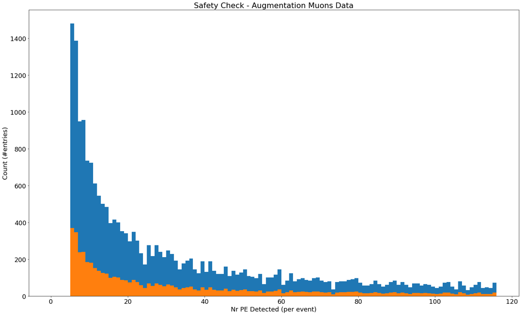

```python
bins = np.linspace(0, 116, 117)
plt.hist(aug_mu_train.sum(axis=1), bins=bins, label="Augmented Muons")
plt.hist(muons_train.pedetected, bins=bins, label="Original Muons")
plt.title("Safety Check - Augmentation Muons Data")
plt.xlabel("Nr PE Detected (per event)")
plt.ylabel("Count (#entries)")
plt.show()
```